# DATA202/472 - 2024 - Assignment 1

Jackson Rakena

2024-03-07

## Q1

1. Numerical continuous, class `numeric`, type `double`
2. Categorical logical, class `logical`, type `logical`
3. Numerical integer, class `numeric`, type `integer`
4. Categorical nominal, class `character`, type `character`
5. Categorical ordinal, class `ordered factor`, type `integer`

## Q2

```r
y <- c("Earth"=0, "Water"=-3, "Fire"=2)
```

```r
y[y==2]
```

```
## Fire
##    2
```

```r
names(y[y==2])
```

```
## [1] "Fire"
```

```r
a <- c(3, 4, 1)
z <- array(c(0,3,0,9,2,1), dim=c(2,3))
print(a)
```

```
## [1] 3 4 1
```

```r
print(z)
```

```
##      [,1] [,2] [,3]
## [1,]    0    0    2
## [2,]    3    9    1
```

```r
max(a)
```

```
## [1] 4
```

## Q3

```r
standardize_column <- function(mat, col) {
  mean <- mean(mat[, col], na.rm=TRUE)
  sd <- sd(mat[, col], na.rm=TRUE)

  return((mat[, col] - mean) / sd)
}
```

```r
mat <- matrix(c(12,1,4,3,NA,9,NA,5,5), nrow=3)
print(standardize_column(mat, 2))
```

```
## [1] -0.7071068         NA  0.7071068
```

```r
standardize_column <- function(mat, col) {
  if (col > ncol(mat) || !is.vector(mat[,col])) {
    stop("col must be a valid index of mat")
  }
  mean <- mean(mat[, col], na.rm=TRUE)
  sd <- sd(mat[, col], na.rm=TRUE)

  return((mat[, col] - mean) / sd)
}
```

```r
print(standardize_column(mat, 0.3))
```

```
## Error in standardize_column(mat, 0.3): col must be a valid index of mat
```

```r
print(standardize_column(mat, -1))
```

```
## Error in standardize_column(mat, -1): col must be a valid index of mat
```

```r
print(standardize_column(mat, 1))
```

```
## [1]  1.1137997 -0.8206945 -0.2931052
```

```r
print(standardize_column(mat, 4))
```

```
## Error in standardize_column(mat, 4): col must be a valid index of mat
```

## Q4

```r
stars <- read.csv("star_dataset_deepu_kaggle.csv", header=TRUE)
```

```r
stars[1:2,]
```

```
##   Temperature..K. Luminosity.L.Lo. Radius.R.Ro. Absolute.magnitude.Mv.
## 1            3068           0.0024       0.1700                  16.12
## 2            3042           0.0005       0.1542                  16.60
##   Star.type Star.color Spectral.Class
## 1         0        Red              M
## 2         0        Red              M
```

```r
nrow(stars)
```

```
## [1] 240
```

```r
ncol(stars)
```

```
## [1] 7
```

```r
subset_stars <- stars[stars$Star.color %in% c("Orange","White","Blue"),]
head(subset_stars)
```

```
##    Temperature..K. Luminosity.L.Lo. Radius.R.Ro. Absolute.magnitude.Mv.
## 22            7740         4.90e-04    1.234e-02                  14.02
## 23            7220         1.70e-04    1.100e-02                  14.23
## 24            8500         5.00e-04    1.000e-02                  14.50
## 31           39000         2.04e+05    1.060e+01                  -4.70
## 50           33750         2.20e+05    2.600e+01                  -6.10
## 54            3749         5.50e+05    1.648e+03                  -8.05
##    Star.type Star.color Spectral.Class
## 22         2      White              A
## 23         2      White              F
## 24         2      White              A
## 31         3       Blue              O
## 50         4       Blue              B
## 54         5     Orange              M
```

```r
is.factor(subset_stars$Star.color)
```

```
## [1] FALSE
```

```r
subset_stars$star_colours <- factor(subset_stars$Star.color, levels = c("Blue", "White", "Orange"))
```

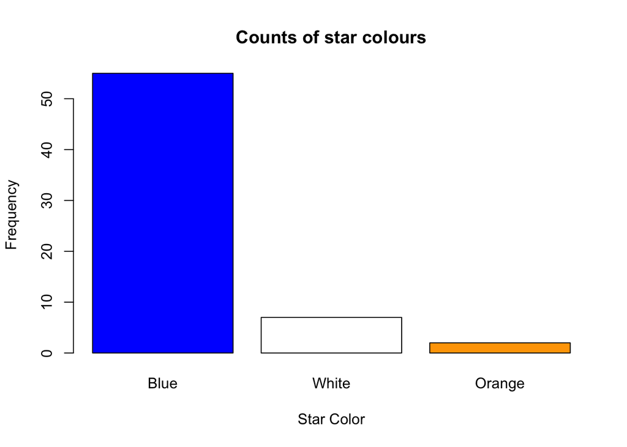

```r
barplot(table(subset_stars$star_colours), main = "Counts of star colours", xlab = "Star Color", ylab = "Frequency", col = c("blue", "white", "orange"))
```

## Q5

1. This statement sets the value of `x` to `y`.
2. This statement checks the equality of `x` and `y`, i.e. that all elements of `x` are identical to `y`.
3. This statement also sets the value of `x` to `y`.
4. This checks that `x` is less than the inverse of `y`.
5. This takes each element of `x` and puts it the power of the the negative value of the element of `y` in the same position.

## Q6

```r
library(palmerpenguins)
```

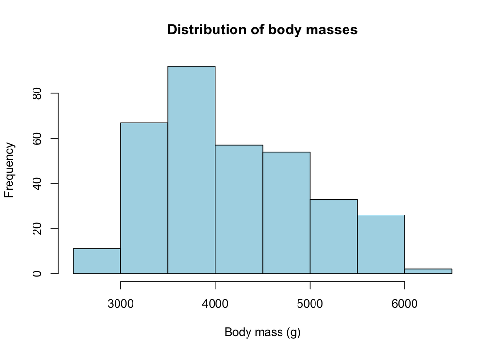

```r
hist(penguins$body_mass_g, main="Distribution of body masses",
     xlab="Body mass (g)", col="lightblue")
```

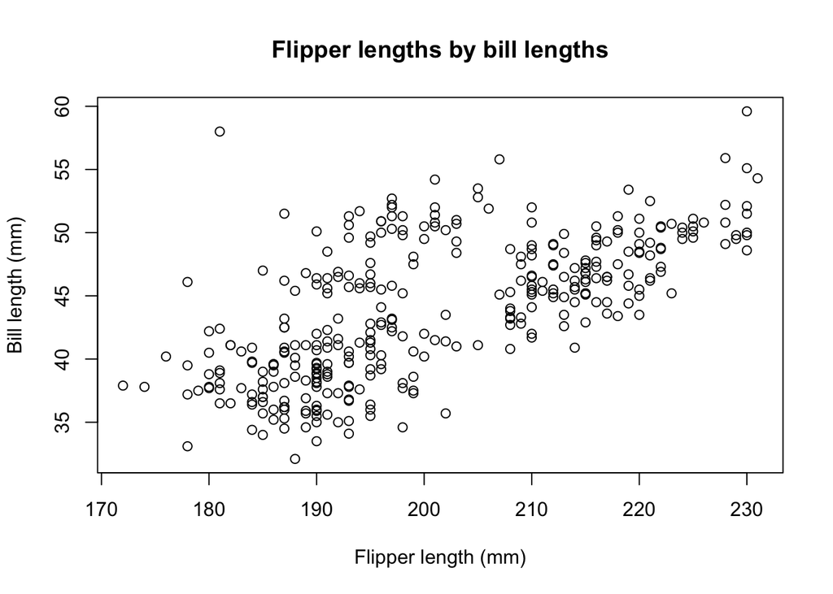

```r
plot(penguins$flipper_length_mm, penguins$bill_length_mm,
     xlab="Flipper length (mm)", ylab="Bill length (mm)",
     main="Flipper lengths by bill lengths")
```

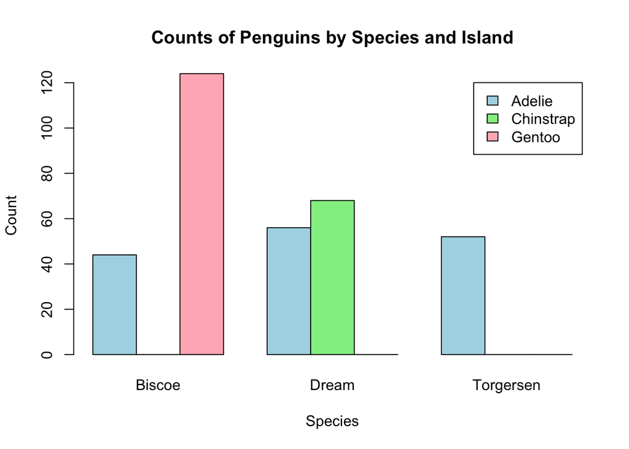

```r
barplot(table(penguins$species, penguins$island),
        main = "Counts of Penguins by Species and Island",
        xlab = "Species",
        ylab = "Count",
        legend.text = TRUE,
        col = c("lightblue", "lightgreen", "lightpink"),
        beside = TRUE)
```

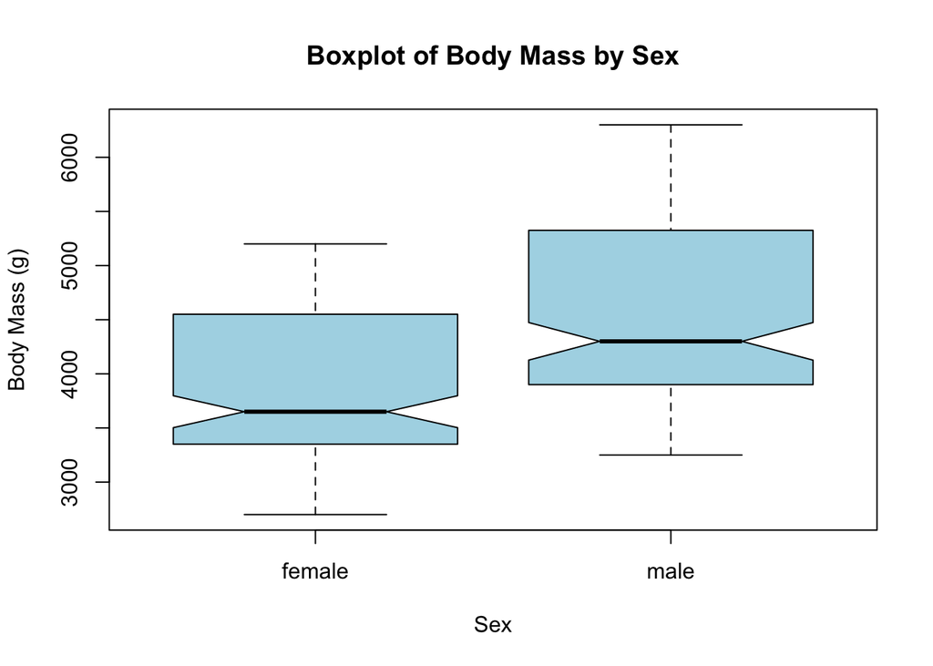

```r
boxplot(penguins$body_mass_g ~ penguins$sex,
        main = "Boxplot of Body Mass by Sex",
        xlab = "Sex",
        ylab = "Body Mass (g)",
        col = c("lightblue", "lightblue"),
        border = "black",
        notch = TRUE)
```

## Q7

Fixed version:

```r
# Define x
x <- c(3,0,5,6,NA,3,1)
# Store the first five entries of x as a new object called y
y <- x[1:5]
# Calculate the maximum value of y after excluding NA entries
max_y <- max(y, na.rm=TRUE)
# Fetch the entries of y that are bigger than 2
y[y > 2]
```

```
## [1]  3  5  6 NA
```

Fixes:

1. Line 2: To define a variable we need to use `<-` instead of `<=`
2. Line 4: We need to use `1:5` to select the first five elements
3. Line 6: We need to use `na.rm` instead of `na.remove` to remove NA elements
4. Line 8: We need to use `>` (bigger than) instead of `>=` (bigger than or equal to) to get elements bigger than 2